# Lógica y Pensamiento Científico

Herramientas deductivas, validez y verdad

Bogdan G. Popescu

bgpopescu@tec.mx

Tecnologico de Monterrey

## Objetivos de aprendizaje

### Al terminar, van a poder:

1. **Distinguir la validez de la solidez**
2. **Usar tres formas de razonamiento confiables**
3. **Detectar y nombrar las dos trampas**

## Ejercicio de repaso

> “La economía de esta región ha crecido todos los trimestres durante los últimos seis años. Así que probablemente crezca el próximo trimestre también.”

Contesten las siguientes preguntas:

1. **¿Deductivo o inductivo?** *(¿promete una garantía, o solo una buena apuesta?)*
2. **¿Se sostiene el enlace?** *(deductivo → ¿válido? · inductivo → ¿fuerte?)*
3. **¿Las premisas son ciertas?**
4. **¿Su veredicto en una palabra?** *(sólido · cogente · o ninguno)*

## Ejercicio de repaso — respuestas

> *“La economía de esta región ha crecido todos los trimestres durante los últimos seis años. Así que probablemente crezca el próximo trimestre también.”*
- **1. Inductivo** — *“probablemente”* promete una buena apuesta, no una garantía.
- **2. Fuerte** — veinticuatro trimestres seguidos, sin contracción. *(La validez ni entra.)*
- **3. Cierta** — es una premisa empírica y, tal como está dicha, se sostiene.
- **4. COGENTE** — enlace fuerte **+** premisas ciertas.

**El tropiezo confiable es agarrar “válido”. Esa palabra le pertenece a la deducción.**

# Parte 1: Calificar un argumento real

## El argumento de los deepfakes

*Como de verdad lo escucharían:*

> “La IA ya puede generar videos que la gente no distingue de uno real. Y cuando la ciudadanía no puede saber qué es real, el discurso democrático queda socavado.”

## El argumento de los deepfakes

**En forma estándar:**

| P1. | **Si** la IA puede generar videos falsos realistas **y** la gente no puede distinguir lo falso de lo real, **entonces** el discurso democrático queda socavado. |
| --- | --- |
| P2. | La IA puede generar videos falsos realistas. |
| P3. | La gente no puede distinguir lo falso de lo real. |
| C. | El discurso democrático queda socavado. |

- **Paso 1 hecho.**
- Paso 2: lo que promete es una **garantía**
- ¿Podrían P1–P3 ser ciertas y C falsa? *(la prueba de validez de la rejilla)*

## La premisa puente

**Tapen P1 con la mano. El argumento deja de funcionar.**

| P2. | La IA puede generar videos falsos realistas. |
| --- | --- |
| P3. | La gente no puede distinguir lo falso de lo real. |
| C. | *Por lo tanto* el discurso democrático queda socavado. |

- Dos hechos sobre **video** — una conclusión sobre **democracia**.
- Nada aquí dice por qué lo primero tocaría lo segundo.

**P1 es el único renglón que menciona ambos.** Los hechos solos nunca concluyen.

**“Pero P1 solo repite las demás.”** Deliberadamente. P2 y P3 dan los **hechos**; P1 da la **regla** que los convierte en conclusión.

## P1 no es el argumento

Un condicional es **un solo enunciado**. Afirma un **enlace** — y nada más.

> *“Si llueve, la calle se moja.”*
- No dice nada sobre si **llovió**.
- No dice nada sobre si la calle **está mojada**.
- Dicho por su cuenta, **no se sigue nada**.

Por eso el argumento necesita **P2 y P3**: afirman lo que P1 solo supone.

## La validez es instantánea

[output not shown]

El **modus ponens** es una regla fundamental de inferencia lógica.

Del latín se traduce como “modo que afirma”

- Sigue una estructura simple de tres pasos: Si P, entonces Q.
- P es cierta. Por lo tanto, Q también tiene que serlo.

## ¿Deducción o inducción?

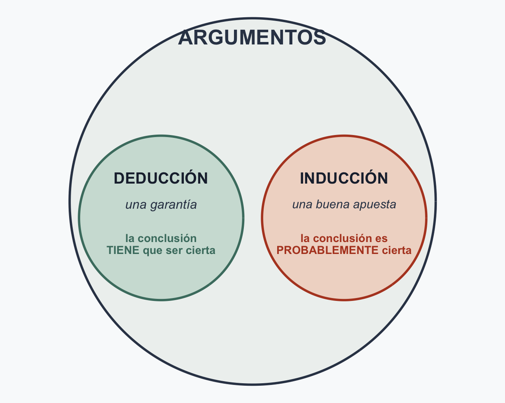

Todo argumento hace una de dos promesas. **Sigue: qué hay dentro de la deducción.**

## Dentro de la deducción

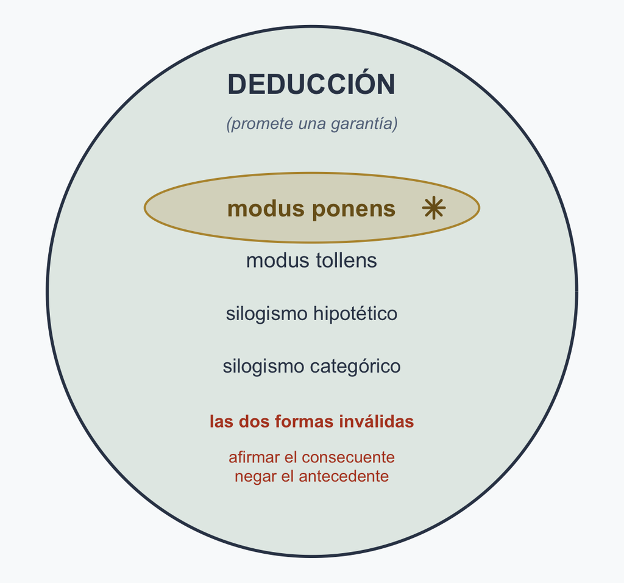

## Poner a prueba la solidez

Dos premisas son **hechos empíricos** — pongan a prueba cada una por su cuenta:

- **P2** *(la IA puede generar falsos realistas)* — **cierta**.
- **P3** *(la gente no puede distinguir lo falso de lo real)* — **¿eso siempre es cierto?**
- **P1** *(el condicional)*: **¿el enlace es cierto?**

| P1. | **Si** la IA puede generar videos falsos realistas **y** la gente no puede distinguir lo falso de lo real, **entonces** el discurso democrático queda socavado. |
| --- | --- |
| P2. | La IA puede generar videos falsos realistas. |
| P3. | La gente no puede distinguir lo falso de lo real. |
| C. | El discurso democrático queda socavado. |

## ¿Qué significa “discurso socavado”?

La frase esconde dos términos vagos:

- ¿qué significa **discurso democrático**?
  - ¿la discusión pública?
  - los foros de comunicación política, como el periodismo
  - el habla que promueve explícitamente la democracia
- ¿qué significa que un discurso quede **socavado**?
  - *(débil)* ¿nada más que circulen algunas falsedades convincentes?
  - ¿se censura a algunas personas?
  - ¿la ciudadanía deja de ver esos foros como creíbles?
  - *(fuerte)* ¿se derrumba la base compartida de lo que es real?

## “Socavado”, en lectura débil

**Lectura débil:** el debate público ahora carga algunas falsedades convincentes.

| P1. | **Si** la IA puede generar videos falsos realistas **y** la gente no puede distinguir lo falso de lo real, **entonces** *el debate público carga algunas falsedades convincentes.* |
| --- | --- |
| P2. | La IA puede generar videos falsos realistas. |
| P3. | La gente no puede distinguir lo falso de lo real. |
| C. | *El debate público carga algunas falsedades convincentes.* |

P1 ahora es plausiblemente cierta.  
C es demasiado tibia para justificar la alarma.  
Siempre han circulado falsedades.

## “Socavado”, en lectura fuerte

**Lectura fuerte:** se derrumba la base compartida de lo que es real.

| P1. | **Si** la IA puede generar videos falsos realistas **y** la gente no puede distinguir lo falso de lo real, **entonces** *se derrumba la base compartida de lo que es real.* |
| --- | --- |
| P2. | La IA puede generar videos falsos realistas. |
| P3. | La gente no puede distinguir lo falso de lo real. |
| C. | *Se derrumba la base compartida de lo que es real.* |

C es la afirmación alarmante: un salto sin probar.  
C ya ni siquiera trata sobre *democracia*:  
- *“lo que es real” ensancha “discurso” hasta toda la realidad.*

Persuade solo porque la lectura *débil* es cierta.  
Esto es **equivocación.**

## Antes de los datos

[video not shown]

¿Real o falso?

¿Qué tan seguros están?

## La afirmación sobre la detección

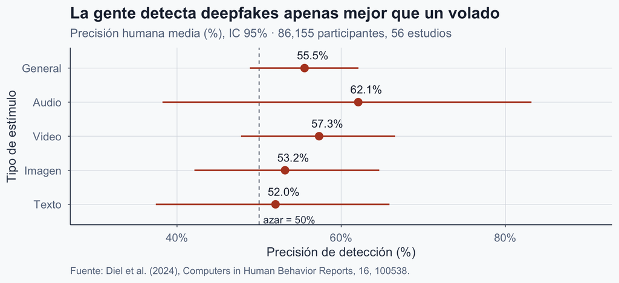

Precisión general: 55.5%.

## El veredicto

**¿Válido?**

- Sí
- si las premisas se sostienen, la conclusión *no puede* ser falsa *(modus ponens)*

**¿Sólido?**

- Para eso hacen falta premisas *ciertas*:
- P3 es absoluta: la gente no puede reconocer deepfakes.
- Pero la gente le atina ~55% de las veces (Diel et al. 2024).

## El veredicto

**¿Válido?**

- Sí
- si las premisas se sostienen, la conclusión *no puede* ser falsa *(modus ponens)*

**¿Sólido?**

- Para eso hacen falta premisas *ciertas*:

Así que P3 — “la gente no puede reconocer deepfakes” — es **falsa:**

- **Válido**: si P1–P3 son correctas, C tiene que seguirse *(modus ponens)*.
- **No sólido**: una *premisa* (P3) es falsa.

## Reparar el argumento

Cambien P3 por la afirmación que la evidencia *sí* sostiene:

| P1. | **Si** la IA puede generar videos falsos realistas **y** la gente los detecta solo un poco mejor que el azar, **entonces** *se derrumba la base compartida de lo que es real.* |
| --- | --- |
| P2. | La IA puede generar videos falsos realistas. |
| P3. | La gente detecta falsificaciones solo **un poco mejor que el azar** *(~55%)*. |
| C. | *Se derrumba la base compartida de lo que es real.* |

- P1 y P3 tenían que cambiar: si debilitas una, debilitas la otra.
- La nueva P1 es una afirmación empírica fresca: más difícil de defender.

**Veredicto final:**

- la forma es **válida**
- la nueva premisa está **sin probar**, así que **no es sólido.**

# Parte 2: Cinco formas — tres herramientas, dos trampas

## Herramienta 1: se cumple la condición, así que se sigue el resultado

**P1:** Si algo es perro, entonces es mamífero.  
**P2:** Fido es perro.  
**C:** Fido es mamífero.

**modus ponens**

Forma: **Si P, entonces Q. P. entonces Q**

**Válido** — se cumple el *si*, así que se sigue el *entonces*.

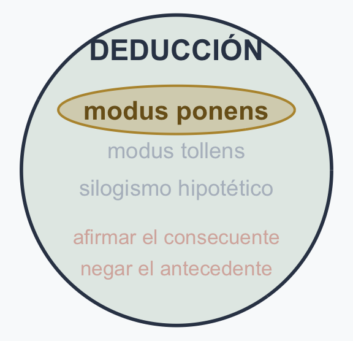

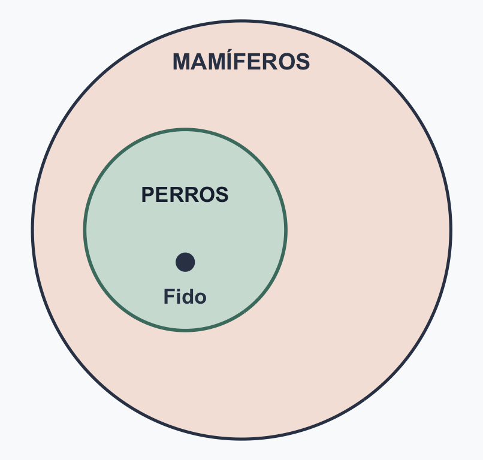

## Herramienta 2: falta el resultado; la condición no se puede cumplir

**P1:** Si algo es perro, entonces es mamífero.  
**P2:** Fido no es mamífero.  
**C:** Fido no es perro.

**modus tollens**

Forma: **Si P, entonces Q. No Q. entonces No P**

**Válido** — la lógica detrás de la *falsación*.

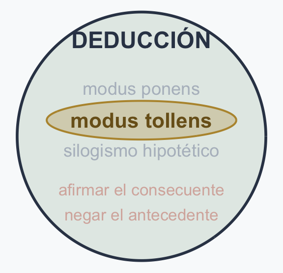

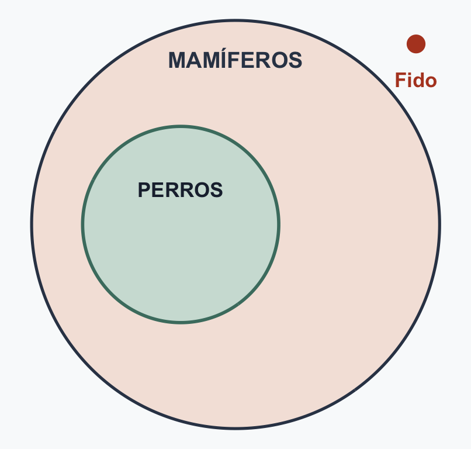

## Herramienta 1 vs. Herramienta 2

| Modus ponens | Modus tollens |
| --- | --- |
| La condición **está presente** | El resultado garantizado **está ausente** |
| Así que el resultado se sigue | Así que la condición queda descartada |
| Si P, entonces Q; P; entonces Q | Si P, entonces Q; no Q; entonces no P |
| *Si perro, entonces mamífero; Fido es perro; entonces mamífero* | *Si perro, entonces mamífero; Fido no es mamífero; entonces no es perro* |

## Herramienta 3: dos reglas se encadenan en una

**P1:** Si perro, entonces mamífero.  
**P2:** Si mamífero, entonces animal.  
**C:** Si perro, entonces animal.

**silogismo hipotético**

Forma: **Si P, entonces Q. Si Q, entonces R. entonces Si P, entonces R**

**Válido** — pero cada eslabón añadido es otra premisa que puede fallar.

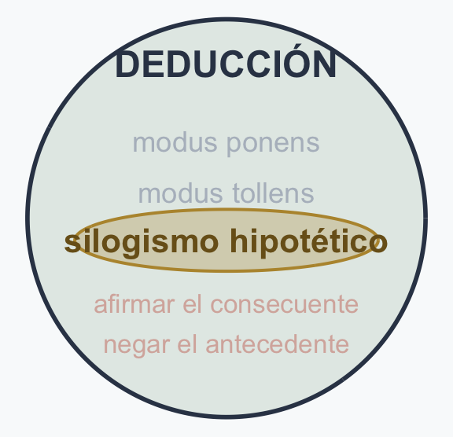

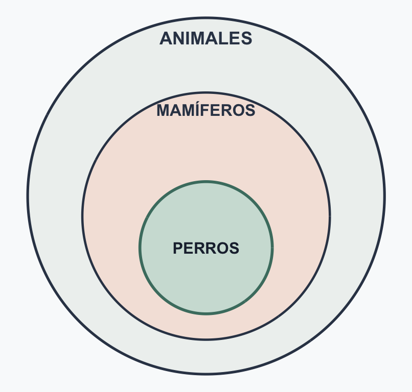

## Perros dentro de mamíferos

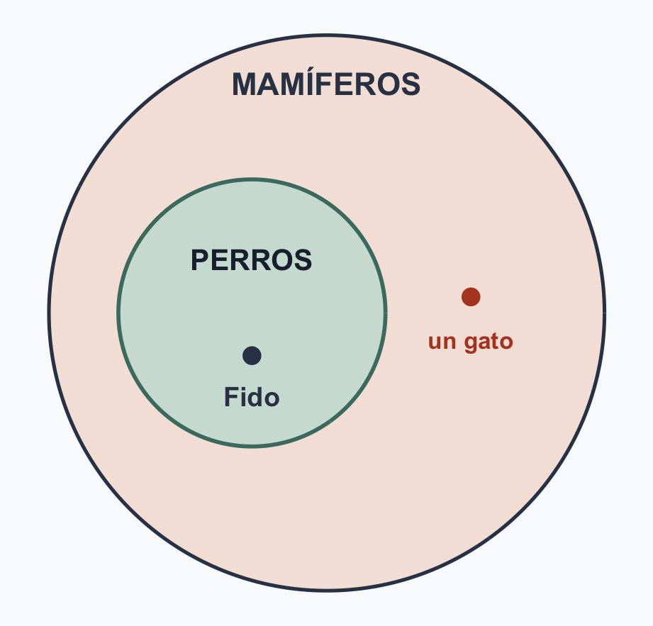

- Dentro de **Perros** → **tiene** que estar dentro de **Mamíferos**: **modus ponens.**
- Fuera de **Mamíferos** → **no puede** estar dentro de **Perros**: **modus tollens.**
- Ese **gato** — un mamífero que no es perro — es la excepción que las dos **trampas** olvidan.

## Herramienta 1 vs. Herramienta 3

| Modus ponens | Silogismo hipotético |
| --- | --- |
| Una regla **más un hecho** | **Dos reglas**, y ningún hecho |
| Si P, entonces Q; **P**; entonces Q | Si P, entonces Q; si Q, entonces R; entonces **si P, entonces R** |
| La conclusión es un **hecho** | La conclusión sigue siendo un **si… entonces** |
| *Fido es perro; entonces Fido es mamífero* | *Si perro, entonces animal — Fido nunca se mencionó* |

**Lean la conclusión.** ¿Todavía trae un *si*? Encadenaron. ¿Es una afirmación seca? Cruzaron.

## Trampa 1: pasó el resultado, entonces se dio esta condición

**P1:** Si algo es perro, entonces es mamífero.  
**P2:** Fido es mamífero.  
**C:** Fido es perro.

Pero Fido podría ser un **gato** — ser perro es solo *una* forma de ser mamífero.

**afirmar el consecuente** *(inválido)*

Forma: **Si P, entonces Q. Q. entonces P**

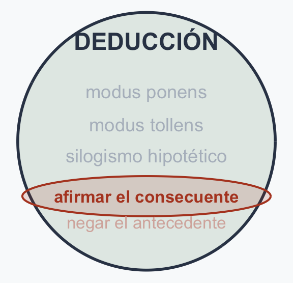

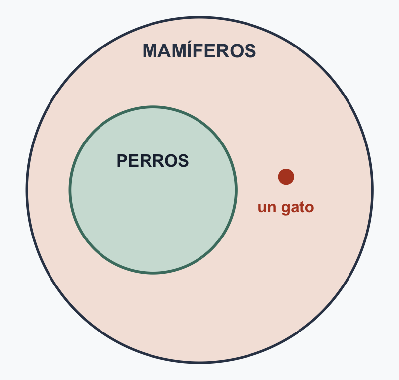

## Trampa 2: la condición está ausente, entonces el resultado también

**P1:** Si algo es perro, entonces es mamífero.  
**P2:** Fido no es perro.  
**C:** Fido no es mamífero.

Pero Fido podría ser un **gato** — no es perro, y sigue siendo mamífero.

**negar el antecedente** *(inválido)*

Forma: **Si P, entonces Q. No P. entonces No Q**

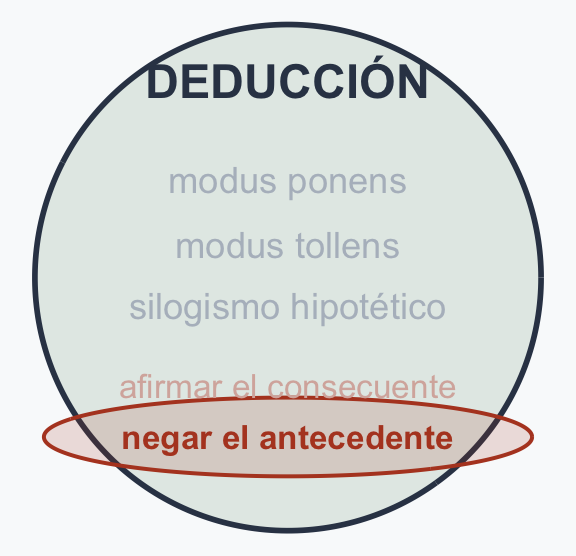

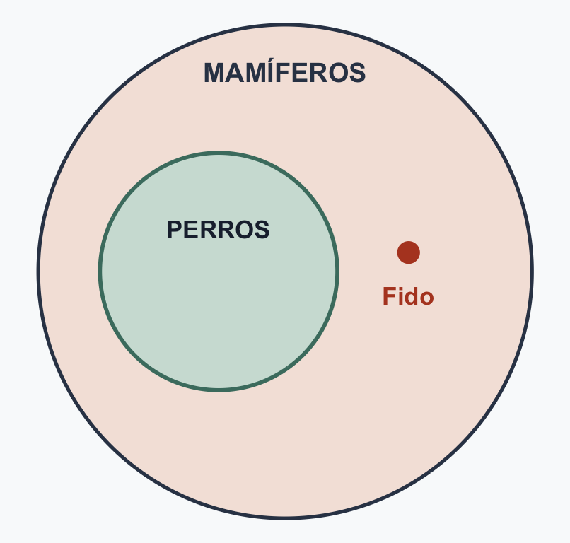

## Herramienta vs. trampa

Cada trampa **invierte** a su contraparte válida *(todas comparten la regla: **Si P, entonces Q**)*:

| Herramienta válida | Contraparte inválida | Dónde se descompone |
| --- | --- | --- |
| **Modus ponens** — *P, entonces Q* | **Afirmar el consecuente** — *Q, entonces P* | lee la regla **al revés** |
| **Modus tollens** — *No Q, entonces No P* | **Negar el antecedente** — *No P, entonces No Q* | olvida que Q puede darse **sin P** *(el gato)* |

Dos preguntas atrapan casi todos los errores: **(1)** ¿Voy en la *dirección* que dice el condicional? **(2)** ¿Era P la *única* ruta hacia Q, o solo *una*?

## Las cinco formas

| Nombre | Movimiento en palabras llanas | Forma | Veredicto |
| --- | --- | --- | --- |
| Modus ponens | Se cumple la condición, se sigue el resultado | Si P, entonces Q. P. entonces Q | VÁLIDO |
| Modus tollens | Falta el resultado, la condición no se cumple | Si P, entonces Q. No Q. entonces No P | VÁLIDO |
| Silogismo hipotético | Dos reglas se encadenan en una | Si P, entonces Q. Si Q, entonces R. entonces Si P, entonces R | VÁLIDO |
| Afirmar el consecuente | Pasó el resultado, entonces se dio esta condición | Si P, entonces Q. Q. entonces P | INVÁLIDO |
| Negar el antecedente | Condición ausente, resultado ausente | Si P, entonces Q. No P. entonces No Q | INVÁLIDO |

Las cinco formas — diapositiva de resumen designada. Según Vaughn (2019).

Memoricen los dos renglones **INVÁLIDOS** — son las dos primeras falacias de la próxima sesión.

# Ejercicio: nombra esa forma

Contesten estas preguntas:

**1.** “Si es perro, entonces es mamífero. Rex es perro. Entonces Rex es mamífero.”

**2.** “Si el video es falso, el detector lo marca. El detector lo marcó. Entonces el video es falso.”

**3.** “Si la vacuna causó el brote, los vacunados se habrían enfermado. No se enfermaron. Entonces no lo causó.”

**4.** “Si ella borró los archivos, es culpable. No los borró. Entonces no es culpable.”

*Respuestas con pregunta dirigida: nombren la forma, luego digan **válida** o **trampa** — y por qué.*

## Nombra esa forma — respuestas

**1.** *“Si es perro, entonces es mamífero. Rex es perro. Entonces Rex es mamífero.”*

- **Modus ponens** → **VÁLIDO**
- Se cumple la condición, así que se sigue el resultado.

**2.** *“Si el video es falso, el detector lo marca. El detector lo marcó. Entonces el video es falso.”*

- **Afirmar el consecuente** — *Trampa 1* → **TRAMPA**
- Los detectores también marcan videos reales. Que lo marque no prueba que sea falso.

**3.** *“Si la vacuna causó el brote, los vacunados se habrían enfermado. No se enfermaron. Entonces no lo causó.”*

- **Modus tollens** → **VÁLIDO**
- Falta el resultado predicho, así que la causa queda descartada.

**4.** *“Si ella borró los archivos, es culpable. No los borró. Entonces no es culpable.”*

- **Negar el antecedente** — *Trampa 2* → **TRAMPA**
- La culpabilidad podría descansar en evidencia completamente distinta.

**Las dos trampas leen la flecha al revés, o borran una ruta que nunca fue la única.**

## Con qué se van

Entraron sabiendo **argumentar.** Salen sabiendo **calificar** — desarmar cualquier argumento y juzgarlo con justicia.

1. **¿Garantía o buena apuesta?** — saben distinguir deducción de inducción.
2. **Válido ≠ sólido** — pueden juzgar la lógica y los hechos *por separado.*
3. **Tres formas confiables, dos trampas que evitar** — nombradas y detectadas.
4. **El argumento de los deepfakes es válido** — así que el desacuerdo real es sobre **hechos.**
5. **Cuando el apoyo es débil, prometan menos** — su hábito de por vida.

## Referencias

- Diel, A., Lalgi, T., Schröter, I. C., MacDorman, K. F., Teufel, M., & Bäuerle, A. (2024). Human performance in detecting deepfakes: A systematic review and meta-analysis of 56 papers. *Computers in Human Behavior Reports, 16*, 100538. https://doi.org/10.1016/j.chbr.2024.100538
- Vaughn, L. (2019). *The power of critical thinking: Effective reasoning about ordinary and extraordinary claims* (6.ª ed.). Oxford University Press. (Cap. 3 — el PDF del curso; el temario lista esta lectura como Vaughn & MacDonald, la edición canadiense.)